# Lab 7: Multiple Linear Regression Intro

Van Gonzales

11/9/2021

```r
knitr::opts_chunk$set(echo = TRUE, message = FALSE, warning = FALSE)
library(tidyverse)
library(palmerpenguins)
library(GGally)
library(broom)
library(kableExtra)
library(modelsummary)
library(stargazer)
```

##Explore Penguins

Use `GGALLY::ggpairs()` to create a pairs plot

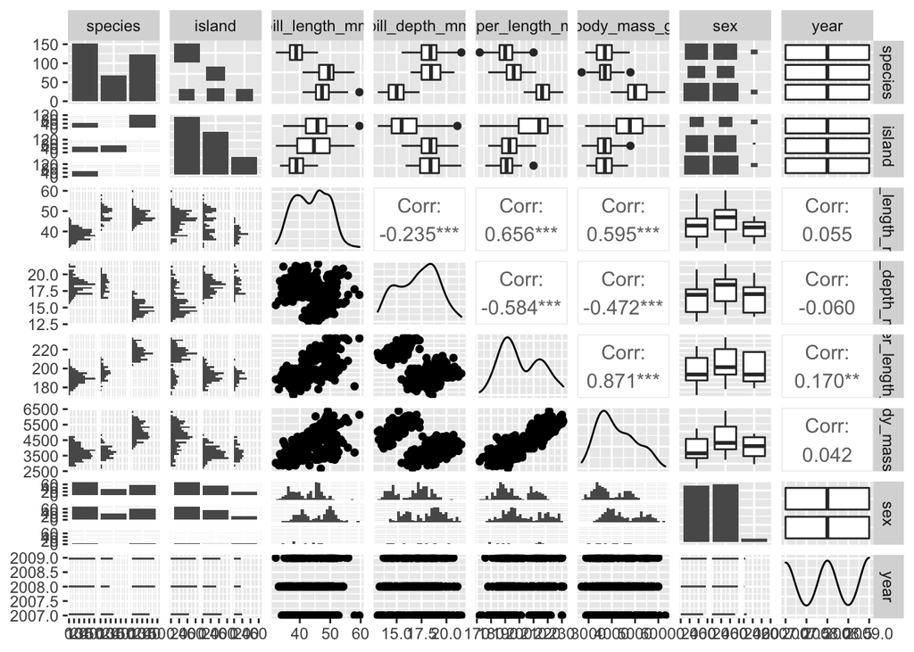

```r
ggpairs(penguins)
```

Thats kind of overkill so let’s simplify the variables that we include in our ggpairs plot:

- species
- bill_length_mm through body_mass_g

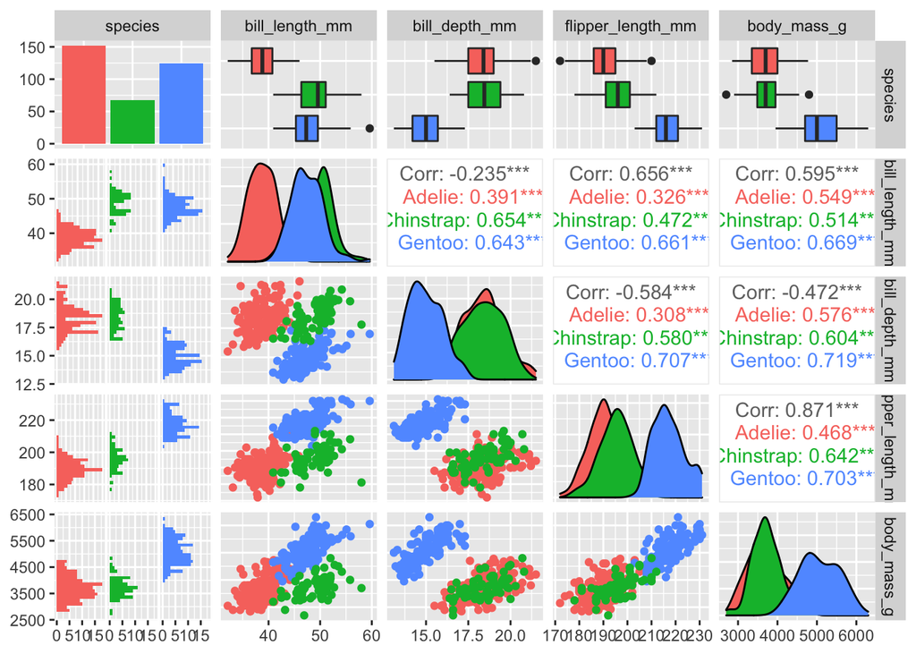

```r
penguins %>%
  select(species, bill_length_mm:body_mass_g) %>%
  ggpairs(aes(color = species))
```

## Multiple Linear Regression

We are going to try to understand a bit better, the relationships between multiple predictor variables and an outcome which is penguin body mass.

The different predictor variables we’re going to try are:

- species
- flipper length
- sex
- bill depth

### Model 1

Model body mass based on only flipper length and bill depth (bad idea, there are important variables missing)

```r
model_1 <- lm(body_mass_g ~ flipper_length_mm + bill_depth_mm, data = penguins)
#Call model by name to return only coefficients
model_1
```

```
##
## Call:
## lm(formula = body_mass_g ~ flipper_length_mm + bill_depth_mm,
##     data = penguins)
##
## Coefficients:
##       (Intercept)  flipper_length_mm      bill_depth_mm
##          -6541.91              51.54              22.63
```

```r
# More info on the coefficients
summary(model_1)
```

```
##
## Call:
## lm(formula = body_mass_g ~ flipper_length_mm + bill_depth_mm,
##     data = penguins)
##
## Residuals:
##      Min       1Q   Median       3Q      Max
## -1029.78  -271.45   -23.58   245.15  1275.97
##
## Coefficients:
##                    Estimate Std. Error t value Pr(>|t|)
## (Intercept)       -6541.907    540.751 -12.098   <2e-16 ***
## flipper_length_mm    51.541      1.865  27.635   <2e-16 ***
## bill_depth_mm        22.634     13.280   1.704   0.0892 .
## ---
## Signif. codes:  0 '***' 0.001 '**' 0.01 '*' 0.05 '.' 0.1 ' ' 1
##
## Residual standard error: 393.2 on 339 degrees of freedom
##   (2 observations deleted due to missingness)
## Multiple R-squared:  0.761,  Adjusted R-squared:  0.7596
## F-statistic: 539.8 on 2 and 339 DF,  p-value: < 2.2e-16
```

If everything else is held constant, we expect that for each 1 mm increase in flipper length, penguin body mass is expected to increase by 51.54 g, on average. The multiple R-squared value menas that, 76.1% of the variance in penguin body mass is described by penguin flipper length and bill depth (the model).

Actually we think that a model for penguin body mass should contain variables species, flipper length, and penguin sex.

```r
model_2 <- lm(body_mass_g ~ species + flipper_length_mm + sex, data = penguins)

# Lets check out the coefficients

model_2
```

```
##
## Call:
## lm(formula = body_mass_g ~ species + flipper_length_mm + sex,
##     data = penguins)
##
## Coefficients:
##       (Intercept)   speciesChinstrap      speciesGentoo  flipper_length_mm
##           -365.82             -87.63             836.26              20.02
##           sexmale
##            530.38
```

```r
#Try interpreting the coefficients for:
#flipper length, Gentoo, male
```

The reference levels are female and species adelie. On average we expect a Gentoo penguin to be 836.26 g larger than an adelie if everything else about them is the same. On average we expect a male penguin to be 530.38 g larger than a female if everything else about them is the same

## Visulaize this model

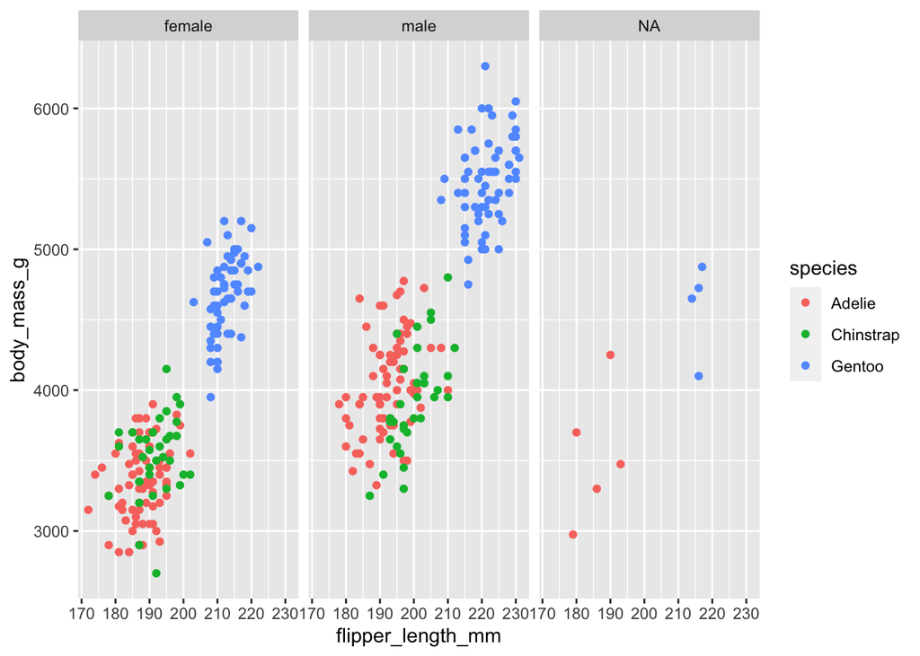

```r
ggplot(data = penguins, aes(x = flipper_length_mm, y = body_mass_g)) +
  geom_point(aes(color = species)) +
  facet_wrap(~sex)
```

## Acouple ways to get & report MLR modle outcomes

Use broom::tidy() to get model coefficient info in a tidy data frame

```r
penguin_model_2_coef <- tidy(model_2)

penguin_model_2_coef
```

```
## # A tibble: 5 × 5
##   term              estimate std.error statistic  p.value
##   <chr>                <dbl>     <dbl>     <dbl>    <dbl>
## 1 (Intercept)         -366.     532.      -0.688 4.92e- 1
## 2 speciesChinstrap     -87.6     46.3     -1.89  5.95e- 2
## 3 speciesGentoo        836.      85.2      9.82  4.11e-20
## 4 flipper_length_mm     20.0      2.85     7.04  1.15e-11
## 5 sexmale              530.      37.8     14.0   2.41e-35
```

Try to write inline code 1r1 that spits out the coefficient for Gentoo. 836.2600081.

## Look at model diagnostics

Use plot() function.

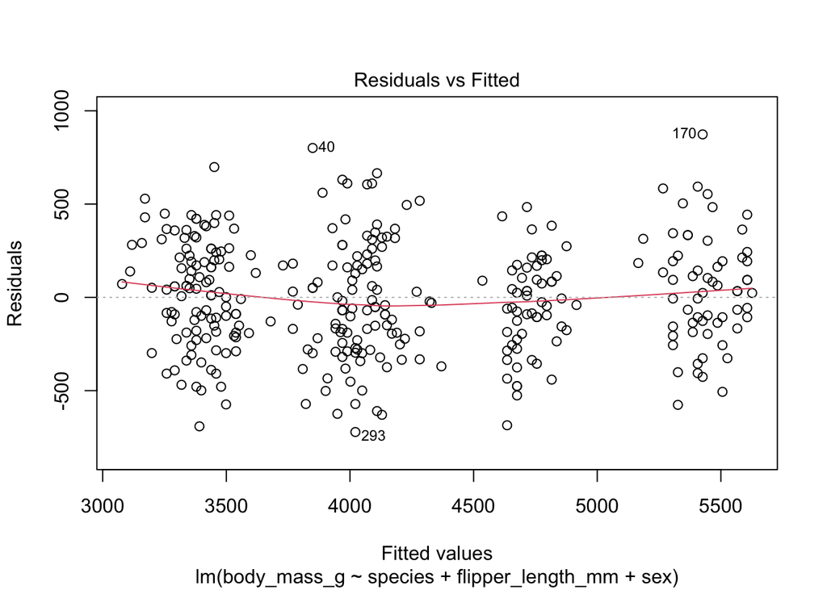

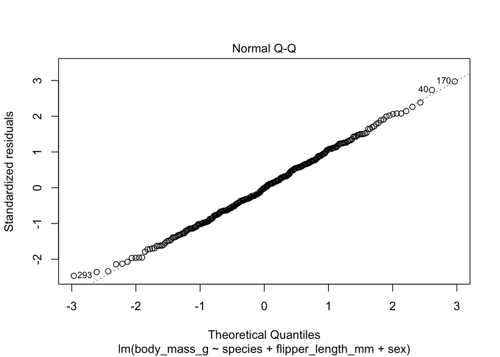

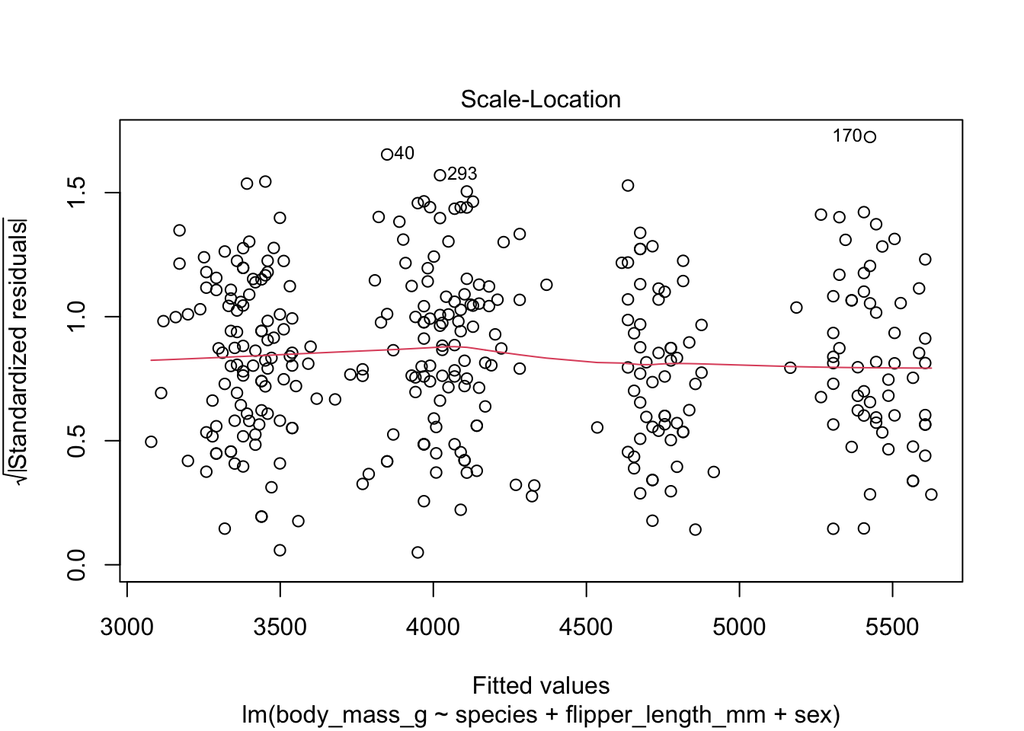

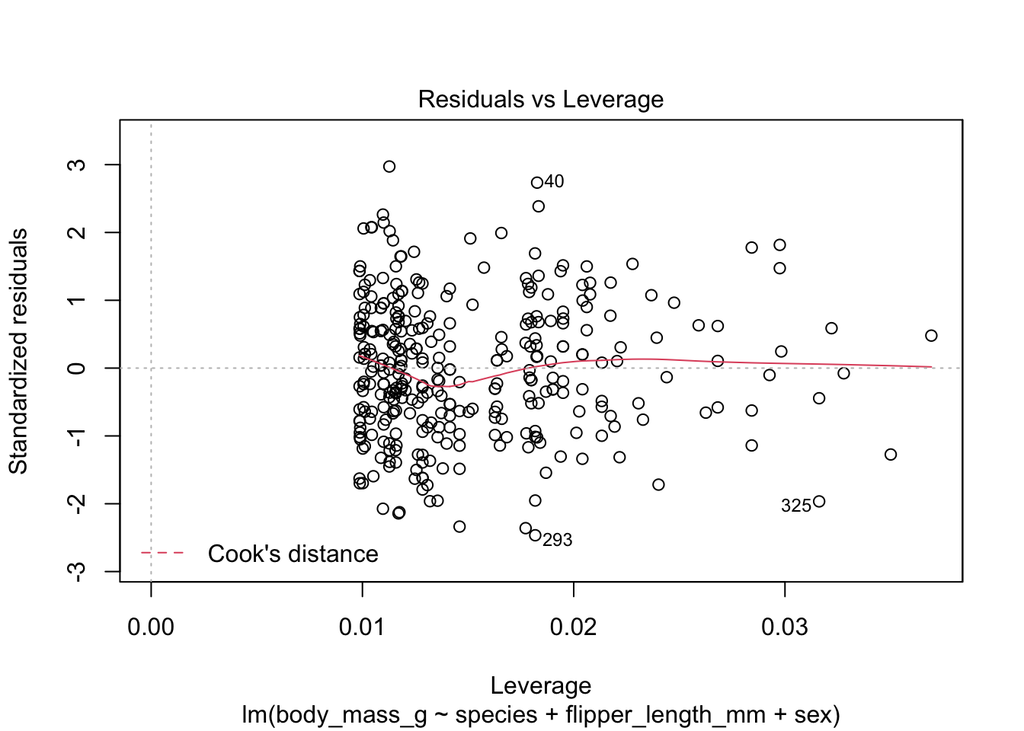

```r
plot(model_2)
```

```r
summary(model_2)
```

```
##
## Call:
## lm(formula = body_mass_g ~ species + flipper_length_mm + sex,
##     data = penguins)
##
## Residuals:
##    Min     1Q Median     3Q    Max
## -721.8 -195.7   -5.9  198.6  873.7
##
## Coefficients:
##                   Estimate Std. Error t value Pr(>|t|)
## (Intercept)       -365.817    532.050  -0.688   0.4922
## speciesChinstrap   -87.634     46.347  -1.891   0.0595 .
## speciesGentoo      836.260     85.185   9.817  < 2e-16 ***
## flipper_length_mm   20.025      2.846   7.037 1.15e-11 ***
## sexmale            530.381     37.810  14.027  < 2e-16 ***
## ---
## Signif. codes:  0 '***' 0.001 '**' 0.01 '*' 0.05 '.' 0.1 ' ' 1
##
## Residual standard error: 295.6 on 328 degrees of freedom
##   (11 observations deleted due to missingness)
## Multiple R-squared:  0.8669, Adjusted R-squared:  0.8653
## F-statistic:   534 on 4 and 328 DF,  p-value: < 2.2e-16
```

## Report the model outputs in a summary table

Use modelsummary:

```r
modelsummary(model_2)
```

|  | Model 1 |
| --- | --- |
| (Intercept) | −365.817 |
|  | (532.050) |
| speciesChinstrap | −87.634 |
|  | (46.347) |
| speciesGentoo | 836.260 |
|  | (85.185) |
| flipper_length_mm | 20.025 |
|  | (2.846) |
| sexmale | 530.381 |
|  | (37.810) |
| Num.Obs. | 333 |
| R2 | 0.867 |
| R2 Adj. | 0.865 |
| AIC | 4740.8 |
| BIC | 4763.6 |
| Log.Lik. | −2364.387 |
| F | 534.024 |

Use stargazer:

```r
stargazer(model_2, type = "html")
```

|  | *Dependent variable:* |
| --- | --- |
|  | body_mass_g |
| speciesChinstrap | -87.634* |
|  | (46.347) |
| speciesGentoo | 836.260*** |
|  | (85.185) |
| flipper_length_mm | 20.025*** |
|  | (2.846) |
| sexmale | 530.381*** |
|  | (37.810) |
| Constant | -365.817 |
|  | (532.050) |
| Observations | 333 |
| R<sup>2</sup> | 0.867 |
| Adjusted R<sup>2</sup> | 0.865 |
| Residual Std. Error | 295.565 (df = 328) |
| F Statistic | 534.024*** (df = 4; 328) |
| *Note:* | p<0.1; p<0.05; p<0.01 |